# calidad_cafe_parte3

```python
import pandas as pd
import numpy as np
import re
import matplotlib.pyplot as plt
import matplotlib.dates as mdates
import seaborn as sns
import missingno as msno

%matplotlib inline

datos = pd.read_csv('/home/emma/Data_Science/mod2_diplomado/coffee_ratings.csv')
```

## Actividad 0: Análisis de valores faltantes del objeto `datos`

**Procedimiento:**

Veemos que `coffee_ratings.csv` contiene evaluaciones de calidad de café de diferentes regiones del mundo. Para el análisis de valores faltantes se calculó, por columna, el conteo absoluto y el porcentaje de valores `NaN` respecto al total de filas, utilizando `isnull().sum()`. El resultado se filtró para mostrar únicamente las columnas con al menos un valor ausente y se ordenó de mayor a menor proporción de faltantes.

**Resultados:**

El dataset contiene **1,339 filas y 43 columnas**. De ellas, **19 columnas presentan al menos un valor faltante**. La columna más afectada es `lot_number` (79.39 %), seguida de `farm_name` (26.81 %) y `mill` (23.75 %).

```python
# datos.info()
```

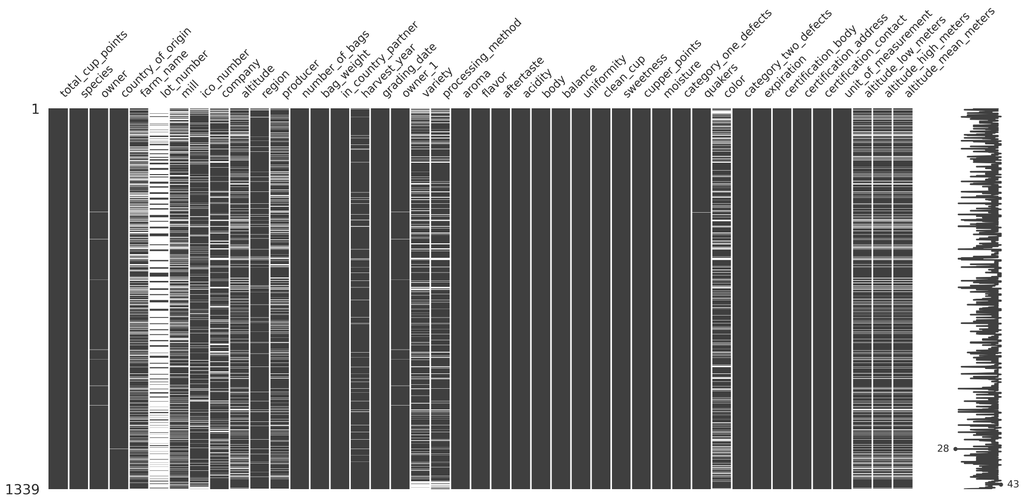

```python
msno.matrix(datos)
# La grafica muestra que tan completos estan los datos por columna
```

```python
total_filas = len(datos)

faltantes = datos.isnull().sum()
pct_faltantes = (faltantes / total_filas * 100).round(2)


resumen_na = pd.DataFrame({
    "valores_faltantes": faltantes,
    "porcentaje": pct_faltantes
})
resumen_na = resumen_na[resumen_na["valores_faltantes"] > 0].sort_values(
    "valores_faltantes", ascending=False
)

print(resumen_na)
```

```
                      valores_faltantes  porcentaje
lot_number                         1063       79.39
farm_name                           359       26.81
mill                                318       23.75
color                               270       20.16
producer                            232       17.33
altitude_high_meters                230       17.18
altitude_low_meters                 230       17.18
altitude_mean_meters                230       17.18
altitude                            226       16.88
variety                             226       16.88
company                             209       15.61
processing_method                   170       12.70
ico_number                          159       11.87
region                               59        4.41
harvest_year                         47        3.51
owner_1                               7        0.52
owner                                 7        0.52
country_of_origin                     1        0.07
quakers                               1        0.07
```

## Actividad 1: Crear la columna `color2` a partir de `color`

**Procedimiento:**

Se definió un diccionario `COLOR_MAP` que asocia cada valor textual de la columna `color` con su código hexadecimal correspondiente (`"Green"` → `"#00FF66"`, `"Bluish-Green"` → `"#CCEBC5"`, `"Blue-Green"` → `"#BFFFFF"`). La columna `color2` se construyó aplicando el método `Series.map()` de pandas sobre `color`; los valores ausentes o no presentes en el diccionario quedan automáticamente como `NaN`, cumpliendo la condición de asignar `NA` cuando `color == NA`. Notamos que a diferencia de R, al leer el cvs de forma predeterminada, pandas detecta automaticamente los `"None"` y los convierte a `NA`

**Resultados:**

La columna `color2` muestra que la mayoría de los granos (870) son Verde (`#00FF66`), 114 son Verde-Azulado (`#CCEBC5`) y 85 son Verde-Azul (`#BFFFFF`). Los 270 valores faltantes originales de `color` se conservan como `NaN` en `color2`.

```python
datos["color"].unique()
```

```
<StringArray>
['Green', nan, 'Bluish-Green', 'Blue-Green']
Length: 4, dtype: str
```

```python
datos["color"].value_counts(dropna=False)
```

```
color
Green           870
NaN             270
Bluish-Green    114
Blue-Green       85
Name: count, dtype: int64
```

```python
COLOR_MAP = {
    "Green": "#00FF66",
    "Bluish-Green": "#CCEBC5",
    "Blue-Green": "#BFFFFF",
}

datos["color2"] = datos["color"].map(COLOR_MAP)

print(datos[["color", "color2"]].value_counts(dropna=False))
```

```
color         color2
Green         #00FF66    870
NaN           NaN        270
Bluish-Green  #CCEBC5    114
Blue-Green    #BFFFFF     85
Name: count, dtype: int64
```

## Actividad 2: Crear la columna numérica `bag_weight2` a partir de `bag_weight`

**Procedimiento:**

Se definió la función `extraer_numero_bag_weight()` que aplica expresiones regulares para extraer el primer valor numérico de la cadena `bag_weight`. Al revisar el vector, se consideraron **ambiguas** las observaciones que contienen una coma (`,`) (p. ej., `"2 kg,lbs"`), en esos casos se asigna `NaN`. Los valores faltantes originales también producen `NaN`.

**Resultados:**

```python
datos["bag_weight"].dtype
```

```
<StringDtype(storage='python', na_value=nan)>
```

Los datos en `bag_weight` son strings.

```python
datos["bag_weight"].unique()
```

```
<StringArray>
[   '60 kg',        '1',    '30 kg',    '69 kg',     '1 kg', '2 kg,lbs',
        '6',    '3 lbs',    '50 kg',    '2 lbs',  '100 lbs',    '15 kg',
     '2 kg',        '2',    '70 kg', '19200 kg',    '5 lbs', '1 kg,lbs',
     '6 kg',    '0 lbs',    '46 kg',    '40 kg',    '20 kg',    '34 kg',
    '1 lbs',   '660 kg', '18975 kg', '12000 kg',    '35 kg',    '66 kg',
    '80 kg',  '132 lbs',     '5 kg',    '25 kg',    '59 kg', '18000 kg',
  '150 lbs',  '9000 kg',    '18 kg',    '10 kg',    '29 kg',  '1218 kg',
    '4 lbs',     '0 kg', '13800 kg',  '1500 kg',    '24 kg',   '80 lbs',
     '8 kg',     '3 kg',   '350 kg',    '67 kg',     '4 kg',   '55 lbs',
   '100 kg',  '130 lbs']
Length: 56, dtype: str
```

Veemos que nuestros strings solo están separados por coma, entonces podemos implementar lo siguiente

```python
datos["bag_weight2"] = np.where(
    datos["bag_weight"].str.contains(",", regex=False),
    np.nan,
    pd.to_numeric(
        datos["bag_weight"].str.extract(r"(\d+)")[0]
    )
)

datos["bag_weight2"] = np.where(
    datos["bag_weight"].str.contains("lb", regex=False),
    datos["bag_weight2"] / 2.205,
    datos["bag_weight2"]
)

datos["bag_weight2"] = np.where(
    datos["bag_weight2"] > 300,
    np.nan,
    datos["bag_weight2"]
)

df2 = datos[["bag_weight", "bag_weight2"]]
df2.sample(15)
```

|  | bag_weight | bag_weight2 |
| --- | --- | --- |
| 868 | 70 kg | 70.000000 |
| 974 | 18975 kg | NaN |
| 140 | 1 kg | 1.000000 |
| 1155 | 69 kg | 69.000000 |
| 1281 | 1 kg | 1.000000 |
| 732 | 60 kg | 60.000000 |
| 471 | 60 kg | 60.000000 |
| 706 | 2 kg | 2.000000 |
| 482 | 60 kg | 60.000000 |
| 671 | 70 kg | 70.000000 |
| 263 | 70 kg | 70.000000 |
| 362 | 1 kg | 1.000000 |
| 1152 | 1 kg | 1.000000 |
| 308 | 100 lbs | 45.351474 |
| 718 | 5 lbs | 2.267574 |

## Actividad 3: Crear las columnas `method1` y `method2` a partir de `processing_method`

**Procedimiento:**

Se utilizó el separador `"/"` (con posibles espacios circundantes) como delimitador para dividir `processing_method` en dos partes: el primer método de procesamiento (`method1`) y el segundo (`method2`). Se consideran **ambiguas** las observaciones que: (1) tienen valor `NaN`, ya que no es posible dividir lo que no existe, o (2) contienen el valor `"Other"`, que no incluye el separador `"/"` y por tanto no puede separarse en dos partes distintas.

**Resultados:**

Las observaciones ambiguas corresponden a todas las filas con `NaN` en `processing_method` (170 filas) más aquellas con el valor `"Other"` que carece del separador necesario. El conteo exacto se muestra en la salida del código a continuación.

```python
datos["processing_method"].unique()
```

```
<StringArray>
[             'Washed / Wet',                         nan,
             'Natural / Dry',    'Pulped natural / honey',
 'Semi-washed / Semi-pulped',                     'Other']
Length: 6, dtype: str
```

```python
separador_pm = r"\s*/\s*"

split_pm = datos["processing_method"].str.split(separador_pm, n=1, expand=True)
datos["method1"] = split_pm[0].str.strip()
datos["method2"] = split_pm[1].str.strip() if 1 in split_pm.columns else np.nan


ambiguos_pm = datos["processing_method"].apply(
    lambda v: pd.isna(v) or "/" not in str(v)
)
print(f"Observaciones ambiguas en processing_method: {ambiguos_pm.sum()}")

df3 = datos[["processing_method", "method1", "method2"]]
df3.sample(10)
```

```
Observaciones ambiguas en processing_method: 196
```

|  | processing_method | method1 | method2 |
| --- | --- | --- | --- |
| 341 | Washed / Wet | Washed | Wet |
| 1079 | NaN | NaN | NaN |
| 172 | Other | Other | NaN |
| 822 | Washed / Wet | Washed | Wet |
| 1261 | NaN | NaN | NaN |
| 1256 | Washed / Wet | Washed | Wet |
| 471 | Natural / Dry | Natural | Dry |
| 1175 | Washed / Wet | Washed | Wet |
| 1114 | Pulped natural / honey | Pulped natural | honey |
| 343 | Natural / Dry | Natural | Dry |

## Actividad 4: Crear las columnas `expiration_day`, `expiration_month` y `expiration_year`

**Procedimiento:**

**Resultados:**

```python
datos["expiration_day"] = pd.DatetimeIndex(datos["expiration"]).day
datos["expiration_month"] = pd.DatetimeIndex(datos["expiration"]).month
datos["expiration_year"] = pd.DatetimeIndex(datos["expiration"]).year

df4 = datos[["expiration", "expiration_day", "expiration_month", "expiration_year"]]
df4.sample(10)
```

|  | expiration | expiration_day | expiration_month | expiration_year |
| --- | --- | --- | --- | --- |
| 1146 | July 28th, 2015 | 28 | 7 | 2015 |
| 39 | March 12th, 2016 | 12 | 3 | 2016 |
| 557 | July 18th, 2012 | 18 | 7 | 2012 |
| 1011 | September 11th, 2013 | 11 | 9 | 2013 |
| 754 | January 22nd, 2013 | 22 | 1 | 2013 |
| 685 | August 14th, 2015 | 14 | 8 | 2015 |
| 809 | June 4th, 2013 | 4 | 6 | 2013 |
| 1122 | June 13th, 2018 | 13 | 6 | 2018 |
| 858 | May 24th, 2011 | 24 | 5 | 2011 |
| 898 | February 3rd, 2016 | 3 | 2 | 2016 |

## Actividad 5: Crear las columnas `harvest_mes` y `harvest_anio` a partir de `harvest_year`

**Procedimiento:**

**Resultados:**

```python
datos["harvest_year"].unique()
```

```
<StringArray>
[                    '2014',                        nan,
                     '2013',                     '2012',
               'March 2010',   'Sept 2009 - April 2010',
               'May-August',                '2009/2010',
                     '2015',                     '2011',
                     '2016',                '2015/2016',
                     '2010',                'Fall 2009',
                     '2017',              '2009 / 2010',
                '2010-2011',                '2009-2010',
              '2009 - 2010',                '2013/2014',
              '2017 / 2018',                      'mmm',
                     'TEST', 'December 2009-March 2010',
                '2014/2015',                '2011/2012',
             'January 2011',                    '4T/10',
              '2016 / 2017',             '23 July 2010',
    'January Through April',                  '1T/2011',
                  '4t/2010',                  '4T/2010',
       'August to December',             'Mayo a Julio',
                  '47/2010',            'Abril - Julio',
                  '4t/2011',      'Abril - Julio /2011',
 'Spring 2011 in Colombia.',                  '3T/2011',
                '2016/2017',                  '1t/2011',
                     '2018',                  '4T72010',
               '08/09 crop']
Length: 47, dtype: str
```

```python
import re

# Patrón para año: 4 dígitos que empiecen con 20
regex_anio = r"20\d{2}"

# Patrón para mes: español + inglés, sin distinguir mayúsculas/minúsculas
regex_mes = (
    r"January|February|March|April|May|June|"
    r"July|August|September|October|November|December|"
    r"Enero|Febrero|Marzo|Abril|Mayo|Junio|"
    r"Julio|Agosto|Septiembre|Octubre|Noviembre|Diciembre"
)

datos["harvest_anio"] = (
    datos["harvest_year"]
    .str.findall(regex_anio)
    .str[-1] # con esto nos quedamos con el ultimo elemento si es que hay mas de uno
)

datos["harvest_mes"] = (
    datos["harvest_year"]
    .str.findall(regex_mes, flags=re.IGNORECASE)
    .str[-1]
)


df5 = datos[["harvest_year", "harvest_anio", "harvest_mes"]]
df5.sample(25)
```

|  | harvest_year | harvest_anio | harvest_mes |
| --- | --- | --- | --- |
| 744 | 2013 | 2013 | NaN |
| 1056 | 2013 | 2013 | NaN |
| 823 | 2014 | 2014 | NaN |
| 1220 | NaN | NaN | NaN |
| 71 | 2013 | 2013 | NaN |
| 782 | 2014 | 2014 | NaN |
| 220 | 2014 | 2014 | NaN |
| 241 | 2017 | 2017 | NaN |
| 630 | 2010-2011 | 2011 | NaN |
| 929 | 2012 | 2012 | NaN |
| 842 | 2015 | 2015 | NaN |
| 1276 | 2012 | 2012 | NaN |
| 347 | 2012 | 2012 | NaN |
| 1195 | 2012 | 2012 | NaN |
| 931 | 2012 | 2012 | NaN |
| 460 | 2014 | 2014 | NaN |
| 273 | 2012 | 2012 | NaN |
| 227 | 2013 | 2013 | NaN |
| 749 | 2012 | 2012 | NaN |
| 1149 | 2013 | 2013 | NaN |
| 298 | 2016 | 2016 | NaN |
| 110 | 2012 | 2012 | NaN |
| 541 | 2015 | 2015 | NaN |
| 1042 | 2014 | 2014 | NaN |
| 837 | 2015 | 2015 | NaN |

## Actividad 6: Visualización de `total_cup_points`, `acidity` y `color2`

**Procedimiento:**

**Resultados:**

La visualización revela que no existe una diferencia marcada en la distribución de `total_cup_points` entre los distintos colores de grano. Los granos "Green" (`#00FF66`) dominan la muestra, mientras que "Bluish-Green" y "Blue-Green" son minoritarios. Se aprecia una correlación positiva moderada entre acidez y puntuación total, independientemente del color.

```python
datos[datos["acidity"] == 0]
# datos[datos["total_cup_points"] == 0]
# Observamos que hay un solo dato incompleto que "ensucia nuestro plot"
# Lo convertimos a NA para ignorarlo:

columnas6 = ["acidity", "total_cup_points"]
datos[columnas6] = datos[columnas6].replace(0, np.nan)

print(datos["acidity"].isnull().sum())
```

```
1
```

```
<function matplotlib.pyplot.show(close=None, block=None)>
```

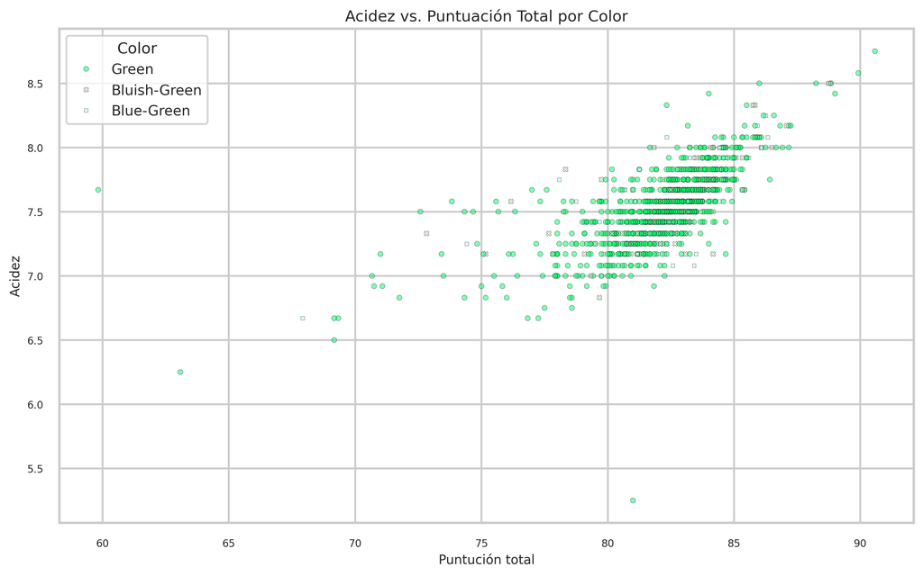

```python
plt.rcParams["figure.dpi"] = 300
sns.set(style="whitegrid", context="talk")
plt.figure(figsize=(12,7))

paleta6 = (datos
    .dropna(subset=["color"])
    .drop_duplicates(subset=["color"])
    .set_index("color")["color2"]
    .to_dict()
)

ax = sns.scatterplot(
    x="total_cup_points",
    y="acidity",
    data=datos,
    hue="color",
    style="color",
    palette=paleta6,
    edgecolor="black",
    alpha=0.5,
    s=16,
)
ax.set_xlabel("Puntución total", fontsize=10)
ax.set_ylabel("Acidez", fontsize=10)
ax.set_title("Acidez vs. Puntuación Total por Color", fontsize=12)
ax.tick_params(axis="both", labelsize=8)
plt.legend(title="Color", fontsize=11, title_fontsize=12)
plt.show
```

## Actividad 7: Visualización de densidad de `bag_weight2` por `species`

**Procedimiento:**

**Resultados:**

```python
df77 = datos["species"] == "Arabica"
df77.sum()
```

```
np.int64(1311)
```

```
<function matplotlib.pyplot.show(close=None, block=None)>
```

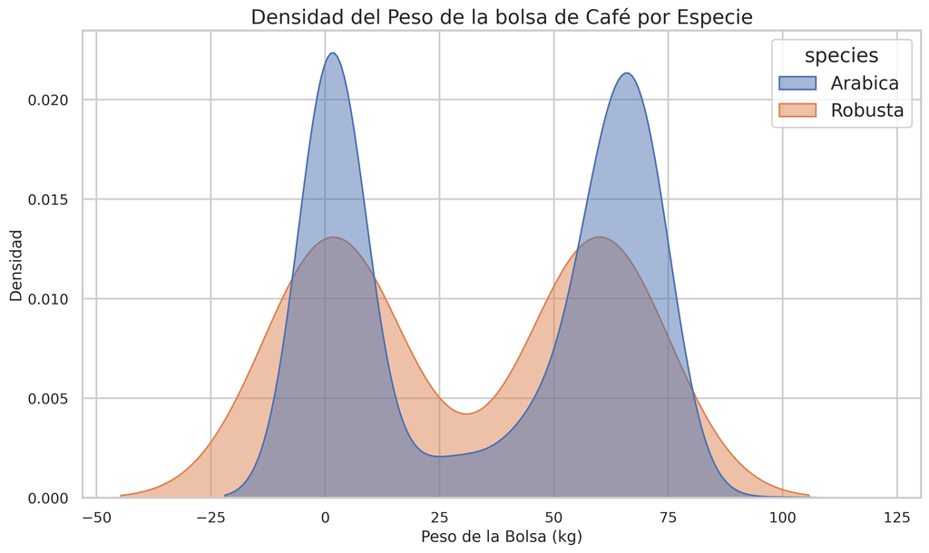

```python
sns.set(style="whitegrid", context="talk")
plt.figure(figsize=(12,7))
g = sns.kdeplot(datos,
                x="bag_weight2",
                hue="species",
                fill=True,
                alpha=0.5,
                linewidth=1.5,
                common_norm=False)

g.set_xlabel("Peso de la Bolsa (kg)", fontsize=14)
g.set_ylabel("Densidad", fontsize=14)
g.tick_params(axis="both", labelsize=13)
plt.tight_layout()
plt.title("Densidad del Peso de la bolsa de Café por Especie")
plt.show
```

## Actividad 8: Fecha de expiración vs `total_cup_points` (México, Brasil, Colombia, Guatemala)

**Procedimiento:**

**Resultados:**

```python
datos["expiration"].unique()
```

```
<StringArray>
[     'April 3rd, 2016',       'May 31st, 2011',     'March 25th, 2016',
  'September 3rd, 2014', 'September 17th, 2013',  'September 2nd, 2011',
     'March 29th, 2016',     'March 26th, 2016',     'March 12th, 2016',
    'August 31st, 2011',
 ...
    'January 4th, 2013',   'October 31st, 2018',      'July 14th, 2015',
   'October 25th, 2018',    'August 17th, 2017',     'August 5th, 2015',
    'August 23rd, 2017',       'May 19th, 2015',      'June 20th, 2014',
  'December 23rd, 2015']
Length: 566, dtype: str
```

```
<function matplotlib.pyplot.show(close=None, block=None)>
```

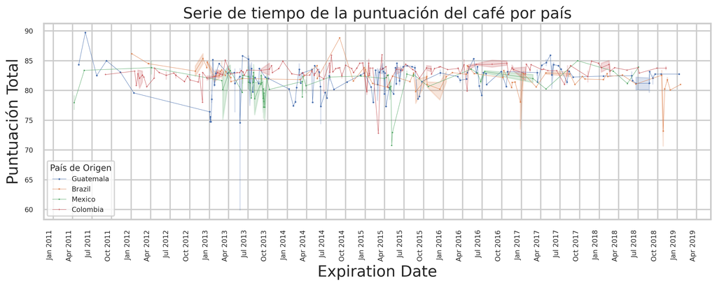

```python
datos["expiration_date"] = pd.to_datetime(
    pd.DataFrame({
        "year": datos["expiration_year"],
        "month": datos["expiration_month"],
        "day": datos["expiration_day"]
    })
)

# Subset del Dataframe de solo los paises seleccionados
countries = ["Mexico", "Brazil", "Colombia", "Guatemala"]
selected_countries = datos[datos["country_of_origin"].isin(countries)]

fig, ax = plt.subplots(figsize=(12, 5))

sns.lineplot(selected_countries,
             x="expiration_date",
             y="total_cup_points",
             hue="country_of_origin",
             style="country_of_origin",
             markers=True,
             dashes=False,
             linewidth=0.4,
             markersize=2,
             markeredgewidth=False,
             ax=ax
)

ax.set(
    xlabel="Expiration Date",
    ylabel="Puntuación Total",
    title="Serie de tiempo de la puntuación del café por país"
)
ax.tick_params(axis="both", labelsize=8)
ax.legend(title="País de Origen", title_fontsize=10, fontsize=8)

ax.xaxis.set_major_locator(mdates.MonthLocator(interval=3))
ax.xaxis.set_major_formatter(mdates.DateFormatter("%b %Y"))
plt.setp(ax.get_xticklabels(), rotation=90, ha="right")

plt.tight_layout()
plt.show
```

## Actividad 9:

##### Elabore una visualización con {ggplot2} que relacione el mes de expiración con el altitude_mean_meters, altitude_low_meters y altitude_high_meters sólo de los granos mexicanos, brasileños, colombianos y guatemaltecos de los años de expiración 2016 y 2017.

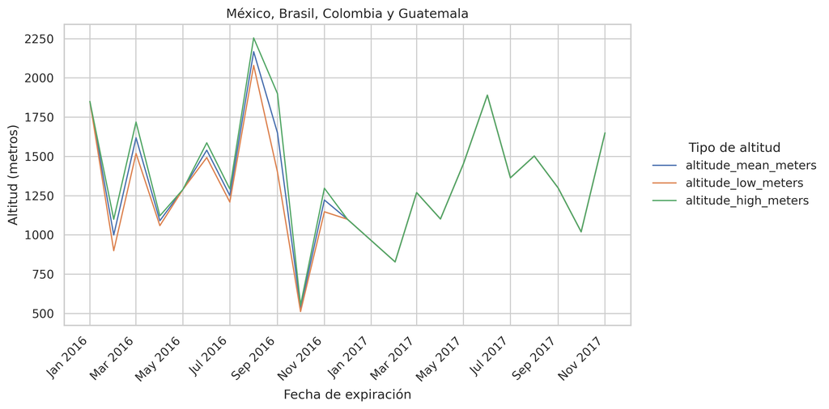

```python
paises = ["Mexico", "Brazil", "Colombia", "Guatemala"]
columnas_altitud = ["altitude_mean_meters",
                    "altitude_low_meters",
                    "altitude_high_meters"]

df_long = (
    datos
    .query("country_of_origin in @paises and expiration_year in [2016, 2017]")
    .assign(fecha_exp=lambda d: pd.to_datetime(
        pd.DataFrame({"year":  d["expiration_year"],
                      "month": d["expiration_month"],
                      "day":   1})
    ))
    .loc[:, ["fecha_exp"] + columnas_altitud]
    .dropna()
    .melt(id_vars="fecha_exp", var_name="tipo_altitud", value_name="altitud")
)

sns.set_theme(style="whitegrid", context="notebook")
fig, ax = plt.subplots(figsize=(11, 5.5))

sns.lineplot(
    data=df_long,
    x="fecha_exp", y="altitud", hue="tipo_altitud",
    estimator="mean",
    errorbar=None,
    linewidth=1.2,
    ax=ax
)

ax.xaxis.set_major_locator(mdates.MonthLocator(interval=2))
ax.xaxis.set_major_formatter(mdates.DateFormatter("%b %Y"))
ax.set(xlabel="Fecha de expiración", ylabel="Altitud (metros)",
       title="México, Brasil, Colombia y Guatemala")
ax.legend(title="Tipo de altitud", loc="center left",
          bbox_to_anchor=(1.02, 0.5), frameon=False)
plt.setp(ax.get_xticklabels(), rotation=45, ha="right")
plt.tight_layout()
plt.show()
```

## Actividad 10: Visualización de `aftertaste`, `acidity`, `body` y `species` en un mismo canvas

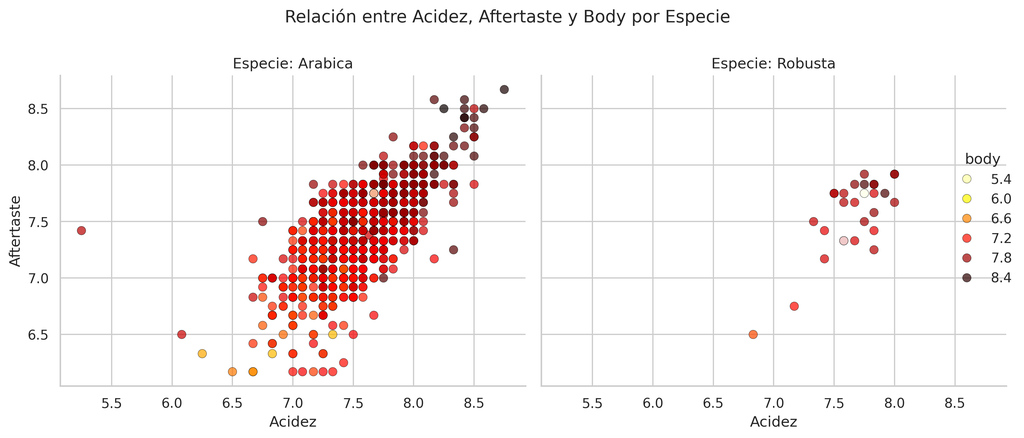

```python
df10 = datos[["aftertaste", "acidity", "body", "species"]].dropna()

g = sns.relplot(
    df10,
    x="acidity",
    y="aftertaste",
    hue="body",
    col="species",
    palette="hot_r",
    alpha=0.7,
    edgecolor="black",
    linewidth=0.3,
    s=50,
    height=5,
    aspect=1.1
)

g.set_axis_labels("Acidez", "Aftertaste")
g.set_titles("Especie: {col_name}")
g.figure.suptitle("Relación entre Acidez, Aftertaste y Body por Especie",
                  y=1, fontsize=14)
plt.tight_layout()
plt.show()
```